# Predicting Car Sales Using k-NN Model

#### **Context and goal:**

In this project, we’ll work on a dataset and use it to predict a car’s market price using its various characteristics, including body style, engine type and horsepower.

The dataset is available at [the UCI Machine Learning Archive](https://archive.ics.uci.edu/ml/datasets/automobile). The dataset and its column names are described in the web site.

**Note:** This code was written on RStudio.  
**Language:** R.  
**Packages:** readr, dplyr, stringr, tidyr, caret, ggplot2.

**Load and read the dataset**

```r
# load the relevant libraries
library(readr)
library(dplyr)
library(stringr)
library(tidyr)
library(caret)
```

```r
library(ggplot2)

# set the working directory
setwd("C:/Users/Aylan/Documents/IT/DataQuest/R/Predicting Car Sales Using a KNN Model")

# read the dataset
cars <- read.table("imports-85.data", sep = ",")

# display the first ten rows
head(cars, 10)
```

```
##    V1  V2          V3  V4    V5   V6          V7  V8    V9   V10   V11  V12
## 1   3   ? alfa-romero gas   std  two convertible rwd front  88.6 168.8 64.1
## 2   3   ? alfa-romero gas   std  two convertible rwd front  88.6 168.8 64.1
## 3   1   ? alfa-romero gas   std  two   hatchback rwd front  94.5 171.2 65.5
## 4   2 164        audi gas   std four       sedan fwd front  99.8 176.6 66.2
## 5   2 164        audi gas   std four       sedan 4wd front  99.4 176.6 66.4
## 6   2   ?        audi gas   std  two       sedan fwd front  99.8 177.3 66.3
## 7   1 158        audi gas   std four       sedan fwd front 105.8 192.7 71.4
## 8   1   ?        audi gas   std four       wagon fwd front 105.8 192.7 71.4
## 9   1 158        audi gas turbo four       sedan fwd front 105.8 192.7 71.4
## 10  0   ?        audi gas turbo  two   hatchback 4wd front  99.5 178.2 67.9
##     V13  V14  V15  V16 V17  V18  V19  V20  V21 V22  V23 V24 V25   V26
## 1  48.8 2548 dohc four 130 mpfi 3.47 2.68  9.0 111 5000  21  27 13495
## 2  48.8 2548 dohc four 130 mpfi 3.47 2.68  9.0 111 5000  21  27 16500
## 3  52.4 2823 ohcv  six 152 mpfi 2.68 3.47  9.0 154 5000  19  26 16500
## 4  54.3 2337  ohc four 109 mpfi 3.19 3.40 10.0 102 5500  24  30 13950
## 5  54.3 2824  ohc five 136 mpfi 3.19 3.40  8.0 115 5500  18  22 17450
## 6  53.1 2507  ohc five 136 mpfi 3.19 3.40  8.5 110 5500  19  25 15250
## 7  55.7 2844  ohc five 136 mpfi 3.19 3.40  8.5 110 5500  19  25 17710
## 8  55.7 2954  ohc five 136 mpfi 3.19 3.40  8.5 110 5500  19  25 18920
## 9  55.9 3086  ohc five 131 mpfi 3.13 3.40  8.3 140 5500  17  20 23875
## 10 52.0 3053  ohc five 131 mpfi 3.13 3.40  7.0 160 5500  16  22     ?
```

```r
# print the dimension of the dataset
print(dim(cars))
```

```
## [1] 205  26
```

**Observations:**

- We can notice that the dataset does not have column names. This means that we have to add them ourselves. We can do this using the attribute information available at [the UCI Machine Learning Archive](https://archive.ics.uci.edu/ml/datasets/automobile).
- The dataset has 205 rows and 26 columns.

Let’s add the column names.

```r
# the column names are available at the UCI ML web site and we'll add them accordingly
# create a vector to store each column name
col_names <- c("symboling", "normalized_losses", "make", "fuel_type", "aspiration", "num_of_doors", "body_style", "drive_wheels", "engine_location", "wheel_base", "length", "width", "height", "curb_weight", "engine_type", "num_of_cylinders", "engine_size", "fuel_system", "bore", "stroke", "compression_ratio", "horsepower", "peak_rpm", "city_mpg", "highway_mpg", "price")

# assign the column names to the dataset
colnames(cars) <- col_names

# display the first ten rows of the dataset
head(cars, 10)
```

```
##    symboling normalized_losses        make fuel_type aspiration num_of_doors
## 1          3                 ? alfa-romero       gas        std          two
## 2          3                 ? alfa-romero       gas        std          two
## 3          1                 ? alfa-romero       gas        std          two
## 4          2               164        audi       gas        std         four
## 5          2               164        audi       gas        std         four
## 6          2                 ?        audi       gas        std          two
## 7          1               158        audi       gas        std         four
## 8          1                 ?        audi       gas        std         four
## 9          1               158        audi       gas      turbo         four
## 10         0                 ?        audi       gas      turbo          two
##     body_style drive_wheels engine_location wheel_base length width height
## 1  convertible          rwd           front       88.6  168.8  64.1   48.8
## 2  convertible          rwd           front       88.6  168.8  64.1   48.8
## 3    hatchback          rwd           front       94.5  171.2  65.5   52.4
```

[output cut: 29 more lines]

**Data cleaning**

Some character type columns in the dataset are not usable for our model because they cannot be converted into numeric. These columns are “make”, “fuel_type”, “aspiration”, “body_style”, “drive_wheels”, “engine_location”, “engine_type”, and “fuel_system”. Let’s remove these columns.

```r
# remove the columns mentioned above
cars <- cars %>%
  select(-make, -fuel_type, -aspiration, -body_style, -drive_wheels, -engine_location, -engine_type,          -fuel_system)

# the column num_of_doors and num_of_cylinders can be converted to numeric type by replacing
# each value by a corresponding numeric number
# first let's list the unique values for each column
print(unique(cars$num_of_doors))
```

```
## [1] "two"  "four" "?"
```

```r
print(unique(cars$num_of_cylinders))
```

```
## [1] "four"   "six"    "five"   "three"  "twelve" "two"    "eight"
```

```r
# replace the values of the column num_of_doors by numeric values
cars$num_of_doors <- cars$num_of_doors %>%
  str_replace_all("two", "2") %>%
  str_replace_all("four", "4")

# replace the values of the column num_of_cylinders by numeric values
cars$num_of_cylinders <- cars$num_of_cylinders %>%
  str_replace_all("four", "4") %>%
  str_replace_all("six", "6") %>%
  str_replace_all("five", "5") %>%
  str_replace_all("three", "3") %>%
  str_replace_all("twelve", "12") %>%
  str_replace_all("two", "2") %>%
  str_replace_all("eight", "8")

# check the unique values again
print(unique(cars$num_of_doors))
```

```
## [1] "2" "4" "?"
```

```r
print(unique(cars$num_of_cylinders))
```

```
## [1] "4"  "6"  "5"  "3"  "12" "2"  "8"
```

```r
# check the datatype of each column
sapply(cars, typeof)
```

```
##         symboling normalized_losses      num_of_doors        wheel_base
##         "integer"       "character"       "character"          "double"
##            length             width            height       curb_weight
##          "double"          "double"          "double"         "integer"
##  num_of_cylinders       engine_size              bore            stroke
##       "character"         "integer"       "character"       "character"
## compression_ratio        horsepower          peak_rpm          city_mpg
##          "double"       "character"       "character"         "integer"
##       highway_mpg             price
##         "integer"       "character"
```

```r
# convert every character type column into numeric column
cars <- cars %>%
  mutate(normalized_losses = as.numeric(normalized_losses),
         num_of_doors = as.numeric(num_of_doors),
         num_of_cylinders = as.numeric(num_of_cylinders),
         bore = as.numeric(bore),
         stroke = as.numeric(stroke),
         horsepower = as.numeric(horsepower),
         peak_rpm = as.numeric(peak_rpm),
         price = as.numeric(price)
         )
# check the datatype of each column
sapply(cars, typeof)
```

```
##         symboling normalized_losses      num_of_doors        wheel_base
##         "integer"          "double"          "double"          "double"
##            length             width            height       curb_weight
##          "double"          "double"          "double"         "integer"
##  num_of_cylinders       engine_size              bore            stroke
##          "double"         "integer"          "double"          "double"
## compression_ratio        horsepower          peak_rpm          city_mpg
##          "double"          "double"          "double"         "integer"
##       highway_mpg             price
##         "integer"          "double"
```

```r
# remove missing values from the cars dataset
cars <- cars %>%
  drop_na()

# check if there is still any missing values
sum(is.na(cars))
```

```
## [1] 0
```

```r
# display the first ten rows of the cleaned dataset
head(cars, 10)
```

```
##    symboling normalized_losses num_of_doors wheel_base length width height
## 1          2               164            4       99.8  176.6  66.2   54.3
## 2          2               164            4       99.4  176.6  66.4   54.3
## 3          1               158            4      105.8  192.7  71.4   55.7
## 4          1               158            4      105.8  192.7  71.4   55.9
## 5          2               192            2      101.2  176.8  64.8   54.3
## 6          0               192            4      101.2  176.8  64.8   54.3
## 7          0               188            2      101.2  176.8  64.8   54.3
## 8          0               188            4      101.2  176.8  64.8   54.3
## 9          2               121            2       88.4  141.1  60.3   53.2
## 10         1                98            2       94.5  155.9  63.6   52.0
##    curb_weight num_of_cylinders engine_size bore stroke compression_ratio
## 1         2337                4         109 3.19   3.40              10.0
## 2         2824                5         136 3.19   3.40               8.0
## 3         2844                5         136 3.19   3.40               8.5
```

[output cut: 18 more lines]

**Data exploration**

First, we need to investigate how the different features are associated with the price variable to see how useful each feature might be to predicting our target variable.

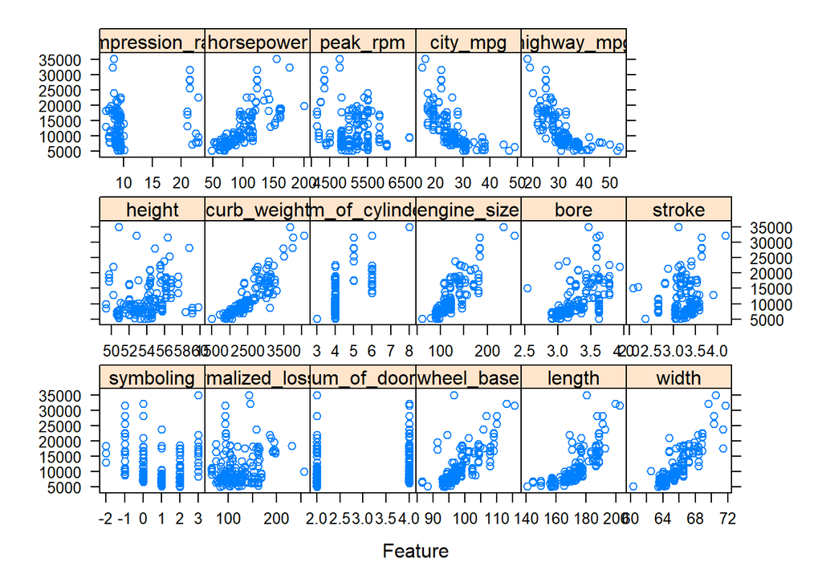

```r
# use the featurePlot() function to create a plot of the dataset
featurePlot(x = cars[1:17],
            y = cars$price,
            plot = "scatter")
```

**Observations:**

- From the plot above, we can see positive relationships between price and the following features: horsepower, curb_weight, engine_size, wheel_base, length, and width. This makes sens since we know that more horsepower and bigger engine size for example increase a car’s price.
- On the other hand, we see negative relationships between those features: highway_mpg and city_mpg and the target variable. The price tends to decrease with a higher mpg.

Next, let’s visualize the distribution of the price variable.

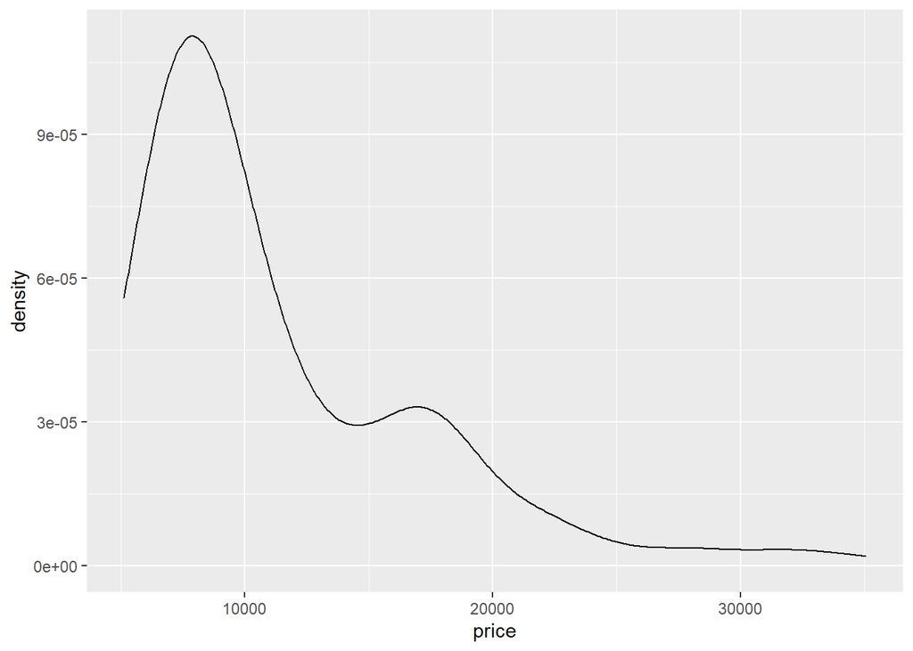

```r
# visualize the distribution of the price variable
ggplot(data = cars,
       aes(x = price)) +
  geom_density()
```

From the density plot, we can say that the variable price is skewed which indicates the presence of outliers which can impact our prediction model negatively. One way to deal with outliers is to remove them. In our case, we can remove every value higher than 20000. This can help reduce the skewness of the data.

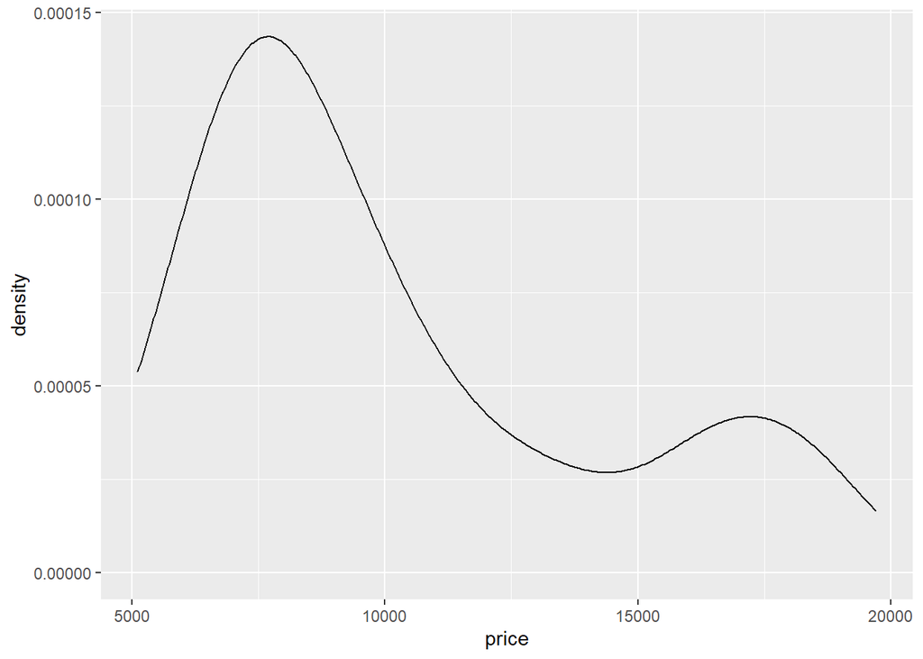

```r
# remove values higher than 20000 for the price variable
cars <- cars %>%
  filter(price < 20000)

# visualize the distribution of the price variable
ggplot(data = cars,
       aes(x = price)) +
  geom_density()
```

```r
# print the number of observations left
nrow(cars)
```

```
## [1] 146
```

After removing the missing values and some outliers, the number of observations went down from 205 to 146.

**Split the data into training and test datasets**

The data is prepared and we now have a better idea of how each feature relates to the target variable price. The next step we need to take is to split the data into training and test sets.

```r
# split the data into training and test sets with a ratio of 80:20
set.seed(1)
train_indices <- createDataPartition(y = cars$price,
                                     p = 0.8,
                                     list = FALSE)
train_set <- cars[train_indices, ]
test_set <- cars[-train_indices, ]

# check the size of the training and test sets
paste("Size of the training set is:", nrow(train_set), "rows and", ncol(train_set), "columns")
```

```
## [1] "Size of the training set is: 118 rows and 18 columns"
```

```r
paste("Size of the test set is:", nrow(test_set), "rows and", ncol(test_set), "columns")
```

```
## [1] "Size of the test set is: 28 rows and 18 columns"
```

The size of the training and test sets matches our expectations.

**Building the model**

In this step, we’ll build our k-NN training model. We’ll use the GridSearch method for hyperparameter optimization.

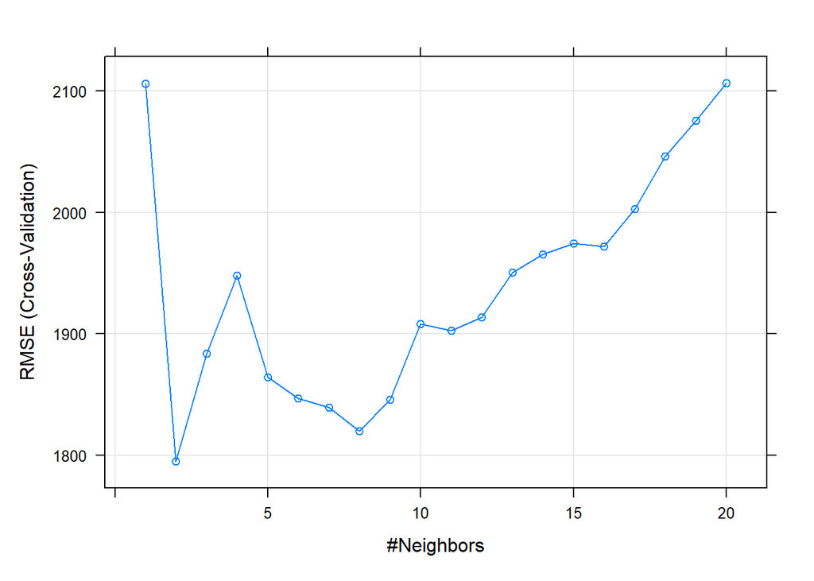

```r
# define the number of k-folds for cross-validation
train_control <- trainControl(method = "cv", number = 10)

# design the parameter tuning grid
grid <- expand.grid(k = 1:20)

# train the model
knn_model <- train(price ~.,
                   data = train_set,
                   method = "knn",
                   trControl = train_control,
                   tuneGrid = grid,
                   preProcess = c("center", "scale"))

# put the knn model into the plot() function to show how each of the hyperparameters performs
plot(knn_model)
```

**Prediction and model evaluation**

Finally, it’s time to make our predictions and evaluate the model against the test data. I use the postResample() function for that.

```r
# evaluate model performance with the postResample() function
predictions <- predict(knn_model, newdata = test_set)
postResample(pred = predictions, obs = test_set$price)
```

```
##        RMSE    Rsquared         MAE
## 1759.866304    0.820245 1344.940476
```

**Conclusion**